# LiP Data Simulation Demo

Erik VonKaenel

2024-08-27

```r
#packages
library(ggplot2)
library(dplyr)
library(OrgMassSpecR)
library(pmartR)
library(tidyverse)
```

```r
#utils
here::i_am("Code/protein_sequence_simulation.R")

source(here::here("Code", "ptm_utils.R"))
source(here::here("Code", "LiP_utils.R"))
```

# Simulating LiP Data

## The data simulation process:

Lets start by generating a single synthetic protein:

```r
lip_data = readr::read_tsv(here::here("Data", "double_pept_lytic_sites.tsv"))

all_peptides = unlist(lapply(lip_data$Sequence, \(x) strsplit(x, split = '; ')[[1]]))

unique_peptides = unique(all_peptides)

amino_acids = unlist(lapply(unique_peptides, \(x) strsplit(x, split = "")[[1]]))

amino_acid_distribution = create_amino_acid_distribution(amino_acids)
```

```r
# set.seed(349)
# set.seed(42)
set.seed(349857)
synthetic_proteins = list(
  generate_protein(2000, amino_acid_distribution)#,
  # generate_protein(1000, amino_acid_distribution)
  )
synthetic_proteins
```

```
## [[1]]
## [1] "PLQDSALGEAGEGFLLGDKRATDNGSLLADNVALEILNGRKTFVIGPYWMTTQNVEELDP…"
```

We mask this protein in chunks to simulate protein folding:

```r
sample_gap = function() rpois(1, 20)
sample_delay = function() rpois(1, 3)
downsample_fn = function(vec, prop) sample(vec, floor(prop * length(vec)))

max_masked_region_size = 100
min_num_trypsin_sites = 2

full_masking = mask_all_proteins(
    sequences = synthetic_proteins,
    delay_fn = sample_delay,
    gap_fn = sample_gap,
    max_masked_region_size = max_masked_region_size,
    min_num_trypsin_sites = min_num_trypsin_sites
  )

full_masking[[1]]$masked_sequence
```

```
## [1] "PLQDSALGEAGEGFLLGDKRAT########################PYWMTTQNVEELDPSRADHRHVVNIVE################NFTTRYLRRRAQKK#######################IPVVAKLTPGVGILATVSLRAAA##############################################LLIRGEGNPYNTDLDEGDRRGV################################VARVEDIGDKGKTDQYELVL################KVAIILL…
```

We interpret this masking as the “full” or “complete” masking, and we simulate group differences with a simple downsampling of the masked regions.

So the masking for group 1:

```r
g1_masking = downsample_maskings(full_masking, downsample_fn, prop = 0.5)
g1_masking[[1]]$masked_sequence
```

```
## [1] "PLQDSALGEAGEGFLLGDKRATDNGSLLADNVALEILNGRKTFVIGPYWMTTQNVEELDPSRADHRHVVNIVEKELEAISPVKPRRELVNFTTRYLRRRAQKK#######################IPVVAKLTPGVGILATVSLRAAAANLDQHNARQAAVDQGSVDSPPFGQADEVVMYLLNIA…###############################PQTKLVGVREKDVDVAER#########################EIDMDHKPYEEHTQIINNVQKRGGARTSAAG…
```

and for group 2:

```r
g2_masking = downsample_maskings(full_masking, downsample_fn, prop = 0.5)
g2_masking[[1]]$masked_sequence
```

```
## [1] "PLQDSALGEAGEGFLLGDKRAT########################PYWMTTQNVEELDPSRADHRHVVNIVE################NFTTRYLRRRAQKKQVNTAQDYAHILKLGEGEKICDGIPVVAKLTPGVGILATVSLRAAA##############################################LLIRGEGNPYNTDLDEGDRRGV################################VARVEDIGDKGKTDQYELVL################KVAIILL…
```

Our goal is to simulate reasonable enough data which can be used to provide guidance on which rollup method(s) can better detect structural differences proteins, i.e. differences in where folded (masked) regions exist. The special spice is how the digestion happens, or more specifically how the digestion is varied across and within subjects. To simulate the two stage digestion in LiP, we start with a masked proteinaise K digestion, followed by an unmasked trypsin digestion.

For both digestion steps, we start with a “perfect” digestion, then downsample and merge cleaved peptides to simulate an imperfect digestion. Below is the perfect proteinase K digestion for group 1:

```r
digest_proteins_PK = function(sequences){
  lapply(sequences, \(x) simulate_proteinase_k_cleavage(x))
}

digest_proteins_trypsin = function(sequences){
  lapply(sequences, \(x) simulate_trypsin_cleavage(x))
}

get_masked_sequences = function(masking_list){
  lapply(masking_list, \(x) x$masked_sequence)
}
get_sequences = function(masking_list){
  lapply(masking_list, \(x) x$sequence)
}

g1_pk_perfect_digestion = digest_proteins_PK(get_masked_sequences(g1_masking))
g2_pk_perfect_digestion = digest_proteins_PK(get_masked_sequences(g2_masking))

g1_pk_perfect_digestion[[1]]# %>% knitr::kable()
```

```
##                                                  peptide start stop
## 1                                                      P     1    1
## 2                                                      L     2    2
## 3                                                   QDSA     3    6
## 4                                                      L     7    7
## 5                                                    GEA     8   10
## 6                                                   GEGF    11   14
## 7                                                      L    15   15
## 8                                                      L    16   16
## 9                                                  GDKRA    17   21
## 10                                                TDNGSL    22   27
## 11                                                     L    28   28
## 12                                                     A    29   29
## 13                                                   DNV    30   32
## 14                                                     A    33   33
```

[output cut: 655 more lines]

We downsample the digestion for proteinase K and trypsin separately by specifying a proportion of cleavages to miss. We can also specify a probability for each cleaveage site to be missed. For now we assume uniform probabilities. Below is one instance of inperfect proteinase K digestion results for group 1 when we miss 50% of proteinase K cleavages:

```r
imperfect_digest = function(
    ptm_site_mapping,
    prop_to_miss,
    prob = NULL
    ){
  n_peps = nrow(ptm_site_mapping)
  # coef_dat = data.frame(peptide = names(peptide_coef), Mult_Factor = exp(peptide_coef))
  # ptm_site_mapping = ptm_site_mapping %>% left_join(., coef_dat, by = "peptide")

  # TODO does the probability of a successful split depend on the peptide length?
  ptm_site_mapping$merge_with_next = seq_len(n_peps) %in% sample(seq_len(n_peps)[-n_peps], round(prop_to_miss * (n_peps - 1)), prob = prob)
  protein = ptm_site_mapping$protein %>% unique()

  remove_vec = rep(FALSE, nrow(ptm_site_mapping))
  # ptm_site_mapping = ptm_site_mapping %>% as_tibble()

  for(i in seq_len(nrow(ptm_site_mapping) - 1)){
    if(ptm_site_mapping$merge_with_next[i]){
      peptide = paste0(ptm_site_mapping$peptide[i], ptm_site_mapping$peptide[i + 1])
      start = ptm_site_mapping$start[i]
      stop = ptm_site_mapping$stop[i + 1]
      remove_vec[i] = TRUE
      merge_with_next = ptm_site_mapping$merge_with_next[i+1]


      ptm_site_mapping$peptide[i + 1] = peptide
      ptm_site_mapping$start[i + 1] = start
      ptm_site_mapping$stop[i + 1] = stop
      ptm_site_mapping$merge_with_next[i + 1] = merge_with_next
    }
  }
  return(ptm_site_mapping[!remove_vec,])
}

adjust_digestions = function(full_digest_results, ...){
  lapply(full_digest_results, \(x) imperfect_digest(x, ...))
}

imperfect_digest(g1_pk_perfect_digestion[[1]], 0.5) %>% select(-merge_with_next) # %>% knitr::kable()
```

```
##                                                      peptide start stop
## 3                                                     PLQDSA     1    6
## 4                                                          L     7    7
## 6                                                    GEAGEGF     8   14
## 7                                                          L    15   15
## 10                                              LGDKRATDNGSL    16   27
## 11                                                         L    28   28
## 14                                                     ADNVA    29   33
## 16                                                       LEI    34   36
## 17                                                         L    37   37
## 19                                                   NGRKTFV    38   44
## 20                                                         I    45   45
## 21                                                        GP    46   47
## 23                                                        YW    48   49
## 24                                                         M    50   50
```

[output cut: 321 more lines]

```r
get_cleavage_site_mapping = function(mask_out, pk_missed_prop, tr_missed_prop, pk_prob = NULL, tr_prob = NULL){
  digest_results_PK = adjust_digestions(digest_proteins_PK(get_masked_sequences(mask_out)), prop_to_miss = pk_missed_prop, prob = pk_prob)
  digest_results_tryp = adjust_digestions(digest_proteins_trypsin(get_sequences(mask_out)), prop_to_miss = tr_missed_prop, prob = tr_prob)

  proteinaseK_cleavage_sites = lapply(digest_results_PK, \(x) x$start[-1])
  trypsin_cleavage_sites = lapply(digest_results_tryp, \(x) x$start[-1])

  PK_dat = lapply(proteinaseK_cleavage_sites, \(x) data.frame(Site = x, PK = 1))
  TR_dat = lapply(trypsin_cleavage_sites, \(x) data.frame(Site = x, TR = -1))
  full_dat = lapply(
    seq_along(PK_dat),
    \(x) full_join(PK_dat[[x]], TR_dat[[x]], by = "Site") %>%
      tidyr::replace_na(., list(PK = 0, TR = 0)) %>%
      mutate(
        sum_col = PK + TR,
        Enzyme = case_match(
        sum_col,
        -1 ~ "Trypsin",
        0 ~ "Proteinase K", # 0 is proteinase K because a trypsin cleavage cannot occur if a PK one already did
        1 ~ "Proteinase K"
      )) %>%
      select(Site, Enzyme) %>%
      arrange(Site)
    )

  return(full_dat)
}
```

```r
# do this once for each protein
cleavage_mapping_example = get_cleavage_site_mapping(
  g1_masking,
  0.5,
  0.5
)

cleavage_mapping_example[[1]] %>% head(10)
```

```
##    Site       Enzyme
## 1     2 Proteinase K
## 2     3 Proteinase K
## 3    17 Proteinase K
## 4    19      Trypsin
## 5    20      Trypsin
## 6    28 Proteinase K
## 7    29 Proteinase K
## 8    30 Proteinase K
## 9    38 Proteinase K
## 10   40      Trypsin
```

```r
get_peptides_before_cleavage = function(sequence, cleavage_site_mapping){
  curr_start = 1
  peptides = c()
  for(i in seq_len(nrow(cleavage_site_mapping))){
    curr_stop = cleavage_site_mapping$Site[i] - 1
    peptides = c(peptides, substr(sequence, start = curr_start, stop = curr_stop))
    curr_start = curr_stop + 1
  }
  return(peptides)
}

get_peptides_after_cleavage = function(sequence, cleavage_site_mapping){
  peptides = c()
  for(i in seq_len(nrow(cleavage_site_mapping) - 1)){
    curr_start = cleavage_site_mapping$Site[i]
    curr_stop = cleavage_site_mapping$Site[i + 1] - 1
    peptides = c(peptides, substr(sequence, start = curr_start, stop = curr_stop))
  }
  curr_start = cleavage_site_mapping$Site[i + 1]
  curr_stop = nchar(sequence)
  peptides = c(peptides, substr(sequence, start = curr_start, stop = curr_stop))

  return(peptides)
}

get_peptide_abundances = function(sequences, cleavage_site_mapping, sequence_abundances = 1){
  prior_peptide_vec = c()
  out = vector("list", length(sequences))
  for(i in seq_along(sequences)){
    peptides_before_cleavage = get_peptides_before_cleavage(
      sequences[[i]],
      cleavage_site_mapping[[i]]
    )
    peptides_after_cleavage = get_peptides_after_cleavage(
      sequences[[i]],
      cleavage_site_mapping[[i]]
    )
    cleavage_site_mapping[[i]]$PriorPeptide = peptides_before_cleavage
    cleavage_site_mapping[[i]]$PosteriorPeptide = peptides_after_cleavage
    out[[i]] = data.frame(peptide = c(peptides_before_cleavage[1], peptides_after_cleavage), start_site = c(1, cleavage_site_mapping[[i]]$Site), abundance = sequence_abundances[i])
  }
  return(list(abundances = out, cleavage_site_mapping = cleavage_site_mapping))
}
```

```r
simulate_protein_for_sample = function(n_reps, mask_out, pk_missed_prop, tr_missed_prop, sequences, pk_prob = NULL, tr_prob = NULL){
  peptide_abundances = vector("list", n_reps)
  cleavage_mappings = vector("list", n_reps)
  for(i in seq_len(n_reps)){
    cleavage_mapping_example = get_cleavage_site_mapping(
      mask_out,
      pk_missed_prop,
      tr_missed_prop,
      pk_prob,
      tr_prob)
    tmp = get_peptide_abundances(
      sequences,
      cleavage_mapping_example)
    peptide_abundances[[i]] = tmp$abundances[[1]]
    cleavage_mappings[[i]] = tmp$cleavage_site_mapping[[1]]
  }
  full_peptide_df = peptide_abundances %>%
    purrr::reduce(., rbind) %>%
    group_by(start_site, peptide) %>%
    summarise(abundance = sum(abundance)) %>%
    ungroup()
  full_cleavage_mapping = cleavage_mappings %>%
    purrr::reduce(., rbind)
    # arrange(start_site)
    return(list(peptide_df = full_peptide_df, cleavage_mapping = full_cleavage_mapping))
}
# test_out = simulate_protein_for_sample(1000, g1_masking, 0.2, 0.2)
# test_out$peptide_df %>% pull(abundance) %>% table %>% hist(breaks = length(.))
```

## Site level rollup: First attempt

### (Relative) Abundance + ANOVA

```r
n_g1 = 20
n_g2 = 20


simulate_protein_for_group = function(n_subjects, group_id, n_reps, mask_out, pk_missed_prop, tr_missed_prop, sequences, pk_prob = NULL, tr_prob = NULL){
  full_pep_list = vector("list", n_subjects)
  full_cleavage_mapping = vector("list", n_subjects)
  for(i in seq_len(n_subjects)){
    out = simulate_protein_for_sample(n_reps, mask_out, pk_missed_prop, tr_missed_prop, sequences, pk_prob, tr_prob)
    full_pep_list[[i]] = out$peptide_df
    full_cleavage_mapping[[i]] = out$cleavage_mapping
  }
  full_pep_list = purrr::reduce(full_pep_list, full_join, by = c("start_site", "peptide"))
  full_cleavage_mapping = purrr::reduce(full_cleavage_mapping, rbind)
  names(full_pep_list)[-c(1, 2)] = paste("subject", seq_len(n_subjects), "group", group_id, sep = '_')
  return(list(peptide_df = full_pep_list, cleavage_mapping = full_cleavage_mapping))
}


g1_dat = simulate_protein_for_group(
  n_g1,
  1,
  200,
  g1_masking,
  0.2,
  0.2,
  synthetic_proteins)

g2_dat = simulate_protein_for_group(
  n_g2,
  2,
  200,
  g2_masking,
  0.2,
  0.2,
  synthetic_proteins)
```

As standard procedure, the abundance data are first log2 transformed then normalized using the median.

```r
full_pep_data = full_join(g1_dat$peptide_df, g2_dat$peptide_df, by = c("peptide", "start_site"))

head(full_pep_data, 50) %>% knitr::kable()
```

| start_site | peptide | subject_1_group_1 | subject_2_group_1 | subject_3_group_1 | subject_4_group_1 | subject_5_group_1 | subject_6_group_1 | subject_7_group_1 | subject_8_group_1 | subject_9_group_1 | subject_10_group_1 | subject_11_group_1 | subject_12_group_1 | subject_13_group_1 | subject_14_group_1 | subject_15_group_1 | subject_16_group_1 | subject_17_group_1 | subject_18_group_1 | subject_19_group_1 | subject_20_group_1 | subject_1_group_2 | subject_2_group_2 | subject_3_group_2 | subject_4_group_2 | subject_5_group_2 | subject_6_group_2 | subject_7_group_2 | subject_8_group_2 | … |
| --- | --- | --- | --- | --- | --- | --- | --- | --- | --- | --- | --- | --- | --- | --- | --- | --- | --- | --- | --- | --- | --- | --- | --- | --- | --- | --- | --- | --- | --- | --- |
| 1 | P | 161 | 161 | 163 | 151 | 165 | 159 | 159 | 160 | 145 | 155 | 167 | 160 | 160 | 156 | 158 | 173 | 165 | 167 | 164 | 161 | 160 | 158 | 148 | 172 | 168 | 162 | 155 | 163 | … |
| 1 | PL | 32 | 37 | 28 | 41 | 30 | 36 | 38 | 33 | 41 | 39 | 30 | 34 | 33 | 38 | 31 | 23 | 31 | 24 | 24 | 34 | 33 | 36 | 42 | 23 | 28 | 31 | 36 | 31 | … |
| 1 | PLQDSA | 3 | 1 | 7 | 4 | 5 | 3 | 3 | 6 | 11 | 5 | 3 | 4 | 5 | 4 | 11 | 3 | 4 | 5 | 7 | 4 | 6 | 5 | 8 | 5 | 3 | 7 | 6 | 6 | … |
| 1 | PLQDSAL | 4 | 1 | 1 | 4 | NA | 2 | NA | 1 | 2 | 1 | NA | 1 | 1 | 2 | NA | NA | NA | 3 | 5 | 1 | 1 | NA | 2 | NA | 1 | NA | 2 | NA | … |
| 2 | L | 129 | 134 | 128 | 119 | 126 | 125 | 130 | 132 | 126 | 129 | 139 | 126 | 131 | 128 | 129 | 137 | 130 | 134 | 127 | 133 | 122 | 127 | 116 | 142 | 134 | 123 | 128 | 129 | … |
| 2 | LQDSA | 28 | 23 | 30 | 26 | 31 | 30 | 24 | 21 | 16 | 22 | 24 | 27 | 22 | 22 | 22 | 30 | 31 | 28 | 29 | 24 | 36 | 23 | 26 | 26 | 29 | 35 | 22 | 26 | … |
| 2 | LQDSAL | 4 | 2 | 4 | 5 | 7 | 4 | 5 | 5 | 1 | 1 | 4 | 6 | 4 | 4 | 6 | 5 | 4 | 4 | 8 | 4 | 2 | 5 | 2 | 2 | 3 | 2 | 4 | 6 | … |
| 3 | QDSA | 127 | 142 | 126 | 124 | 124 | 130 | 135 | 125 | 134 | 122 | 138 | 119 | 141 | 125 | 131 | 135 | 127 | 122 | 130 | 132 | 131 | 123 | 126 | 135 | 128 | 124 | 129 | 132 | … |
| 3 | QDSAL | 29 | 26 | 18 | 27 | 27 | 24 | 23 | 32 | 28 | 36 | 26 | 32 | 18 | 34 | 25 | 22 | 32 | 31 | 20 | 27 | 20 | 30 | 24 | 27 | 27 | 26 | 28 | 25 | … |
| 3 | QDSALGEA | 4 | 2 | 10 | 8 | 5 | 6 | 10 | 5 | 4 | 8 | 4 | 7 | 3 | 7 | 3 | 2 | 2 | 5 | 1 | 7 | 3 | 5 | 2 | 3 | 6 | 3 | 6 | 2 | … |
| 3 | QDSALGEAGEGF | 1 | 1 | 2 | 1 | NA | 1 | NA | 2 | 1 | 1 | 1 | 1 | 1 | NA | 1 | 1 | NA | NA | NA | 1 | 1 | 5 | 6 | NA | 1 | 1 | 1 | 1 | … |
| 7 | L | 127 | 133 | 126 | 125 | 123 | 128 | 128 | 122 | 125 | 121 | 135 | 116 | 137 | 120 | 136 | 137 | 123 | 128 | 138 | 127 | 140 | 112 | 130 | 140 | 128 | 127 | 123 | 133 | … |
| 7 | LGEA | 27 | 25 | 30 | 21 | 29 | 26 | 26 | 22 | 29 | 26 | 23 | 29 | 24 | 22 | 20 | 25 | 29 | 23 | 23 | 27 | 24 | 31 | 27 | 19 | 25 | 33 | 25 | 25 | … |
| 7 | LGEAGEGF | 4 | 6 | 4 | 5 | 6 | 8 | 8 | 5 | 6 | 2 | 6 | 4 | 7 | 8 | 5 | 4 | 7 | 3 | 4 | 4 | 8 | 5 | 3 | 6 | 6 | 4 | 4 | 5 | … |
| 8 | GEA | 114 | 129 | 121 | 127 | 133 | 123 | 129 | 133 | 135 | 122 | 131 | 131 | 132 | 131 | 129 | 119 | 130 | 128 | 136 | 120 | 139 | 118 | 127 | 126 | 127 | 135 | 125 | 132 | … |
| 8 | GEAGEGF | 39 | 23 | 24 | 27 | 20 | 29 | 20 | 21 | 17 | 28 | 25 | 17 | 19 | 23 | 31 | 34 | 23 | 31 | 28 | 29 | 19 | 22 | 25 | 35 | 25 | 12 | 25 | 26 | … |
| 8 | GEAGEGFL | 10 | 9 | 3 | 6 | 4 | 4 | 5 | 5 | 4 | 8 | 7 | 4 | 8 | 6 | 6 | 9 | 6 | 6 | 6 | 6 | 5 | 4 | 4 | 5 | 6 | 7 | 5 | 5 | … |
| 8 | GEAGEGFLL | 1 | 1 | 1 | 1 | NA | 1 | 2 | NA | NA | 1 | 1 | 1 | 1 | NA | 1 | 1 | NA | 1 | 1 | 4 | NA | 3 | 2 | 2 | 1 | NA | 1 | 1 | … |
| 11 | GEGF | 119 | 132 | 135 | 121 | 128 | 128 | 132 | 126 | 133 | 131 | 125 | 131 | 129 | 130 | 126 | 120 | 130 | 129 | 125 | 126 | 130 | 132 | 124 | 120 | 126 | 143 | 132 | 133 | … |
| 11 | GEGFL | 22 | 20 | 24 | 30 | 30 | 24 | 21 | 30 | 31 | 20 | 29 | 30 | 26 | 22 | 22 | 19 | 27 | 21 | 33 | 22 | 26 | 22 | 29 | 25 | 29 | 23 | 20 | 21 | … |
| 11 | GEGFLL | 3 | 4 | 4 | 5 | 9 | 2 | 10 | 4 | 6 | 4 | 3 | 6 | 4 | 8 | 3 | 9 | 4 | 5 | 2 | 4 | 9 | 3 | 5 | 3 | 3 | 7 | 5 | 3 | … |
| 11 | GEGFLLGDK | 1 | NA | NA | NA | NA | NA | NA | NA | NA | NA | NA | NA | NA | NA | 1 | NA | NA | NA | NA | NA | 1 | NA | 1 | NA | NA | NA | NA | 1 | … |
| 15 | L | 134 | 136 | 131 | 125 | 129 | 136 | 132 | 126 | 122 | 121 | 127 | 124 | 121 | 133 | 128 | 121 | 125 | 130 | 125 | 131 | 116 | 130 | 123 | 122 | 123 | 123 | 124 | 123 | … |
| 15 | LL | 23 | 18 | 30 | 26 | 21 | 23 | 20 | 24 | 27 | 33 | 26 | 22 | 31 | 20 | 24 | 32 | 30 | 24 | 27 | 24 | 33 | 30 | 27 | 32 | 31 | 28 | 30 | 27 | … |
| 15 | LLGD | 6 | 5 | 4 | 2 | 4 | 5 | 5 | 4 | 8 | 6 | 2 | 3 | 4 | 7 | 10 | 6 | 4 | 6 | 3 | 4 | 7 | 3 | 6 | 7 | 4 | 7 | 5 | 11 | … |
| 16 | L | 124 | 133 | 133 | 128 | 135 | 134 | 125 | 133 | 122 | 117 | 132 | 138 | 125 | 127 | 126 | 113 | 121 | 124 | 141 | 132 | 121 | 131 | 130 | 119 | 133 | 124 | 121 | 111 | … |
| 16 | LGD | 34 | 27 | 22 | 32 | 28 | 26 | 24 | 20 | 28 | 30 | 25 | 16 | 25 | 29 | 27 | 27 | 28 | 26 | 16 | 20 | 22 | 20 | 18 | 22 | 19 | 25 | 28 | 32 | … |
| 16 | LGDK | 5 | 4 | 4 | 3 | 1 | 4 | 5 | 11 | 8 | 2 | 6 | 4 | 6 | 4 | 6 | 8 | 10 | 4 | 7 | 9 | 5 | 5 | 7 | 9 | 6 | 3 | 2 | 4 | … |
| 16 | LGDKRA | 3 | 3 | 1 | 1 | 1 | 1 | 3 | 1 | NA | 1 | NA | 1 | 1 | NA | NA | 2 | NA | 2 | NA | NA | NA | 2 | 1 | 2 | 1 | 3 | NA | 2 | … |
| 17 | GD | 127 | 123 | 143 | 136 | 131 | 129 | 122 | 122 | 118 | 120 | 127 | 132 | 130 | 118 | 125 | 120 | 123 | 126 | 141 | 140 | 128 | 134 | 117 | 126 | 136 | 125 | 124 | 111 | … |
| 17 | GDK | 18 | 27 | 22 | 21 | 31 | 26 | 31 | 36 | 30 | 30 | 28 | 29 | 29 | 29 | 20 | 30 | 30 | 23 | 24 | 21 | 28 | 27 | 36 | 27 | 26 | 32 | 31 | 29 | … |
| 17 | GDKRA | 4 | 6 | 4 | 2 | 3 | 4 | 3 | 2 | 5 | 5 | 7 | 4 | 1 | 9 | 8 | 4 | 3 | 4 | 5 | 2 | 6 | 4 | 11 | 3 | 6 | 2 | 2 | 2 | … |
| 17 | GDKRATDNGSL | 2 | NA | NA | 1 | NA | NA | NA | 1 | 2 | NA | 1 | 2 | 1 | NA | 1 | 1 | NA | 2 | 2 | 1 | NA | NA | NA | NA | NA | NA | NA | NA | … |
| 19 | K | 136 | 121 | 141 | 140 | 126 | 135 | 110 | 112 | 129 | 135 | 126 | 123 | 126 | 127 | 129 | 125 | 119 | 126 | 136 | 121 | 127 | 115 | 114 | 125 | 121 | 128 | 131 | 131 | … |
| 19 | KRA | 26 | 31 | 23 | 24 | 31 | 24 | 30 | 33 | 19 | 22 | 27 | 28 | 31 | 23 | 25 | 20 | 28 | 29 | 17 | 41 | 25 | 34 | 24 | 27 | 32 | 22 | 20 | 20 | … |
| 19 | KRATDNGSL | 4 | 5 | 5 | 4 | 6 | 2 | 9 | 3 | 5 | 2 | 3 | 3 | 5 | 4 | 5 | 8 | 7 | 5 | 6 | 2 | NA | NA | NA | NA | NA | NA | NA | NA | … |
| 19 | KRATDNGSLLA | 1 | NA | NA | NA | NA | NA | NA | NA | NA | NA | NA | NA | NA | NA | NA | NA | NA | NA | NA | 1 | NA | NA | NA | NA | NA | NA | NA | NA | … |
| 20 | RA | 128 | 120 | 136 | 129 | 126 | 140 | 122 | 130 | 131 | 138 | 128 | 132 | 129 | 121 | 120 | 128 | 127 | 133 | 139 | 120 | 137 | 117 | 122 | 123 | 121 | 126 | 134 | 140 | … |
| 20 | RATDNGSL | 24 | 32 | 23 | 26 | 27 | 15 | 24 | 19 | 29 | 21 | 27 | 21 | 27 | 34 | 27 | 27 | 25 | 19 | 21 | 26 | NA | NA | NA | NA | NA | NA | NA | NA | … |
| 20 | RATDNGSLL | 7 | 3 | 7 | 9 | 4 | 10 | 3 | 9 | 7 | 7 | 5 | 6 | 5 | 2 | 8 | 8 | 6 | 3 | 5 | 5 | NA | NA | NA | NA | NA | NA | NA | NA | … |
| 20 | RATDNGSLLA | 1 | NA | NA | 1 | 1 | 1 | NA | NA | NA | 2 | 2 | 1 | NA | 2 | 1 | 1 | 1 | NA | 4 | 1 | NA | NA | NA | NA | NA | NA | NA | NA | … |
| 22 | TDNGSL | 126 | 129 | 134 | 129 | 125 | 133 | 132 | 138 | 130 | 145 | 130 | 141 | 130 | 122 | 131 | 113 | 132 | 132 | 125 | 126 | NA | NA | NA | NA | NA | NA | NA | NA | … |
| 22 | TDNGSLL | 26 | 23 | 25 | 22 | 30 | 26 | 21 | 23 | 21 | 20 | 25 | 16 | 24 | 28 | 18 | 33 | 23 | 30 | 26 | 32 | NA | NA | NA | NA | NA | NA | NA | NA | … |
| 22 | TDNGSLLA | 6 | 5 | 2 | 5 | 5 | 10 | 4 | 3 | 4 | 1 | 7 | 6 | 7 | 2 | 4 | 6 | 4 | 7 | 8 | 5 | NA | NA | NA | NA | NA | NA | NA | NA | … |
| 22 | TDNGSLLADNV | 2 | 3 | 2 | NA | NA | NA | NA | 1 | NA | 1 | NA | 2 | 1 | 1 | 1 | 1 | NA | NA | 2 | NA | NA | NA | NA | NA | NA | NA | NA | NA | … |
| 22 | TDNGSLLADNVA | 1 | NA | 1 | NA | 1 | NA | 1 | 1 | NA | NA | NA | NA | NA | NA | NA | NA | NA | NA | NA | NA | NA | NA | NA | NA | NA | NA | NA | NA | … |
| 28 | L | 128 | 133 | 133 | 125 | 125 | 122 | 139 | 136 | 141 | 135 | 129 | 142 | 123 | 126 | 135 | 113 | 128 | 129 | 127 | 129 | NA | NA | NA | NA | NA | NA | NA | NA | … |
| 28 | LA | 20 | 25 | 26 | 25 | 30 | 22 | 20 | 22 | 21 | 29 | 24 | 18 | 35 | 28 | 28 | 29 | 29 | 21 | 20 | 21 | NA | NA | NA | NA | NA | NA | NA | NA | … |
| 28 | LADNV | 7 | 8 | 3 | 8 | 1 | 5 | 6 | 3 | 3 | 4 | 5 | 7 | 4 | 4 | 1 | 5 | 5 | 9 | 7 | 5 | NA | NA | NA | NA | NA | NA | NA | NA | … |
| 28 | LADNVA | 1 | NA | NA | 1 | 2 | 1 | 1 | 1 | 1 | 1 | 1 | NA | 1 | 2 | NA | 2 | 2 | NA | NA | NA | NA | NA | NA | NA | NA | NA | NA | NA | … |

```r
generate_f_data = function(full_abundance_df){
  subject_ids = names(full_abundance_df)[-which(names(full_abundance_df) %in% c('start_site', 'peptide'))]
  f_data = data.frame(Subject_IDs = subject_ids) %>%
  mutate(Group_IDs = sapply(strsplit(Subject_IDs, '_'), function(x) x[4]))
  return(f_data)
}

f_data = generate_f_data(full_pep_data)


pep_data = pmartR::as.pepData(
  e_data = full_pep_data %>% ungroup() %>% mutate(Peptide_Site = paste(start_site, peptide, sep = '_')) %>% select(-start_site, -peptide),
  f_data = f_data,
  edata_cname = "Peptide_Site",
  fdata_cname = "Subject_IDs")

pep_data = pep_data %>%
  pmartR::edata_transform(., 'log2') %>%
  pmartR::normalize_global(., "all", "median", apply_norm = T)

full_pep_data = pep_data$e_data %>%
  mutate(
    peptide = sapply(Peptide_Site, \(x) strsplit(x, split = '_')[[1]][2]),
    start_site = as.numeric(sapply(Peptide_Site, \(x) strsplit(x, split = '_')[[1]][1]))
    ) %>%
  select(-Peptide_Site)
```

Here we roll up to the cleavage site level by taking the mean of the abundance for all measured peptides adjacent to each cleavage site. The log2 fold change is computed for each site across groups. Note that we separate the analysis for proteinase K and trypsin sites.

```r
full_cleavage_mapping = rbind(
  g1_dat$cleavage_mapping %>% distinct,
  g2_dat$cleavage_mapping %>% distinct
  ) %>%
  distinct() %>%
  pivot_longer(c("PriorPeptide", "PosteriorPeptide"), values_to = "Peptide", names_to = "Type")


data_for_rollup = full_pep_data %>%
  rename(Site = start_site, Peptide = peptide) %>%
  left_join(., full_cleavage_mapping, by = c("Site", "Peptide")) %>%
  drop_na(., Enzyme, Type)

rolled_up_data = data_for_rollup %>% group_by(Site, Enzyme) %>% select(-Type) %>% summarize_if(is.numeric, mean, na.rm = T)
```

```r
site_data = pmartR::as.pepData(
  e_data = rolled_up_data %>% ungroup() %>% mutate(Site_Type = paste(Site, Enzyme, sep = '_')) %>% select(-Site, -Enzyme),
  f_data = f_data,
  edata_cname = "Site_Type",
  fdata_cname = "Subject_IDs",
  data_scale = "log2")


site_data = site_data %>% group_designation(., main_effects = "Group_IDs")
res = site_data %>% imd_anova(., test_method = "anova")
```

Here is a plot visualing the estimated fold change across sites for both proteinase K and trypsin cleavage sites (black line). The filled in background regions indicate the masking pattern of the sequence across groups.

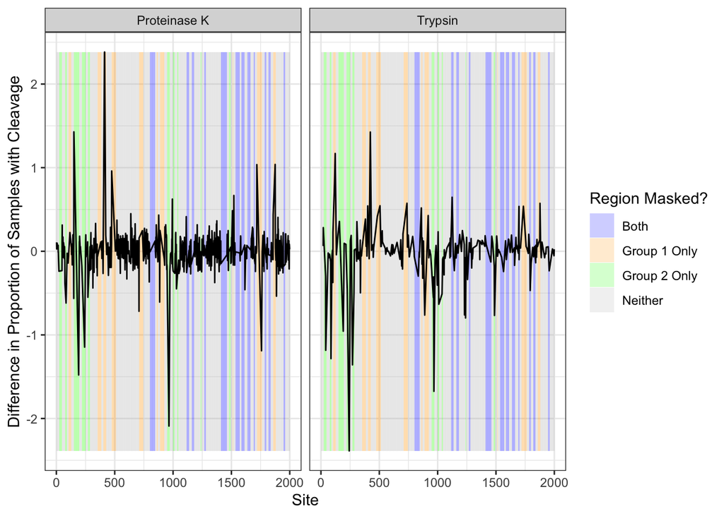

```r
ggdat = res %>%
  select(Site_Type,
         Fold_change_1_vs_2) %>%
  rename(FC = Fold_change_1_vs_2) %>%
  mutate(
    Site = as.numeric(sapply(Site_Type, \(x) strsplit(x, split = '_')[[1]][1])),
    Enzyme = sapply(Site_Type, \(x) strsplit(x, split = '_')[[1]][2])
    ) %>%
  select(-Site_Type)

masking_data = data.frame(
  Site = seq_len(nchar(g1_masking[[1]]$sequence)),
  group_1 = strsplit(g1_masking[[1]]$masked_sequence, '')[[1]],
  group_2 = strsplit(g2_masking[[1]]$masked_sequence, '')[[1]]) %>%
  mutate(
    cat = paste0(group_1, group_2),
    category = case_when(
      cat == "##" ~ "Both",
      grepl("#[A-Za-z]", cat) ~ "Group 1 Only",
      grepl("[A-Za-z]#", cat) ~ "Group 2 Only",
      grepl("[A-Za-z][A-Za-z]", cat) ~ "Neither"
    )
  )

# Create a complete sequence of Sites
all_sites <- data.frame(Site = seq(min(masking_data$Site), max(masking_data$Site)))

# Merge all_sites with ggdat and masking_data
plot_data_1 <- all_sites %>%
  left_join(masking_data, by = "Site") %>%
  mutate(Enzyme = "Trypsin")
plot_data_2 <- all_sites %>%
  left_join(masking_data, by = "Site") %>%
  mutate(Enzyme = "Proteinase K")
plot_data = rbind(plot_data_1, plot_data_2) %>%
  select(-group_1, -group_2, -cat) %>%
  left_join(., ggdat, by = c("Site", "Enzyme"))

# Separate the data for the line plot (where FC is not NA)
line_data <- plot_data %>%
  filter(!is.na(FC))

# Creating the plot with faceting
ggplot() +
  geom_tile(data = plot_data, aes(x = Site, y = (max(line_data$FC, na.rm = TRUE) + min(line_data$FC, na.rm = TRUE)) / 2, fill = category), height = max(line_data$FC, na.rm = TRUE) - min(line_data$FC, na.rm = TRUE), alpha = 0.2) +
  geom_line(data = line_data, aes(x = Site, y = FC)) +
  theme_bw() +
  scale_fill_manual(values = c("Neither" = "gray", "Both" = "blue", "Group 1 Only" = "orange", "Group 2 Only" = "green")) +
  labs(fill = "Region Masked?") +
  ylab("Difference in Proportion of Samples with Cleavage") +
  facet_wrap(~ Enzyme)
```

## Problem!

```r
data_for_rollup %>% filter(Site %in% 136:159 & Enzyme == "Proteinase K") %>% knitr::kable()
```

| subject_1_group_1 | subject_2_group_1 | subject_3_group_1 | subject_4_group_1 | subject_5_group_1 | subject_6_group_1 | subject_7_group_1 | subject_8_group_1 | subject_9_group_1 | subject_10_group_1 | subject_11_group_1 | subject_12_group_1 | subject_13_group_1 | subject_14_group_1 | subject_15_group_1 | subject_16_group_1 | subject_17_group_1 | subject_18_group_1 | subject_19_group_1 | subject_20_group_1 | subject_1_group_2 | subject_2_group_2 | subject_3_group_2 | subject_4_group_2 | subject_5_group_2 | subject_6_group_2 | subject_7_group_2 | subject_8_group_2 | subject_9_group_2 | subject_10_group_2 | … |
| --- | --- | --- | --- | --- | --- | --- | --- | --- | --- | --- | --- | --- | --- | --- | --- | --- | --- | --- | --- | --- | --- | --- | --- | --- | --- | --- | --- | --- | --- | --- |
| 2.6438562 | 2.6438562 | 2.6205864 | 2.6322682 | 2.7333543 | 2.7970130 | 2.7224660 | 2.7224660 | 2.5484366 | 2.7224660 | 2.6780719 | 2.6088092 | 2.6892992 | 2.6780719 | 2.7655347 | 2.6780719 | 2.5360529 | 2.7224660 | 2.6553518 | 2.8278190 | 2.6892992 | 2.6667566 | 2.5360529 | 2.6189098 | 2.6322682 | 2.5384199 | 2.6780719 | 2.6322682 | 2.4150375 | 2.7333543 | … |
| 2.6438562 | 2.6438562 | 2.6205864 | 2.6322682 | 2.7333543 | 2.7970130 | 2.7224660 | 2.7224660 | 2.5484366 | 2.7224660 | 2.6780719 | 2.6088092 | 2.6892992 | 2.6780719 | 2.7655347 | 2.6780719 | 2.5360529 | 2.7224660 | 2.6553518 | 2.8278190 | 2.6892992 | 2.6667566 | 2.5360529 | 2.6189098 | 2.6322682 | 2.5384199 | 2.6780719 | 2.6322682 | 2.4150375 | 2.7333543 | … |
| 2.6438562 | 2.6438562 | 2.6205864 | 2.6322682 | 2.7333543 | 2.7970130 | 2.7224660 | 2.7224660 | 2.5484366 | 2.7224660 | 2.6780719 | 2.6088092 | 2.6892992 | 2.6780719 | 2.7655347 | 2.6780719 | 2.5360529 | 2.7224660 | 2.6553518 | 2.8278190 | 2.6892992 | 2.6667566 | 2.5360529 | 2.6189098 | 2.6322682 | 2.5384199 | 2.6780719 | 2.6322682 | 2.4150375 | 2.7333543 | … |
| 2.6438562 | 2.6438562 | 2.6205864 | 2.6322682 | 2.7333543 | 2.7970130 | 2.7224660 | 2.7224660 | 2.5484366 | 2.7224660 | 2.6780719 | 2.6088092 | 2.6892992 | 2.6780719 | 2.7655347 | 2.6780719 | 2.5360529 | 2.7224660 | 2.6553518 | 2.8278190 | 2.6892992 | 2.6667566 | 2.5360529 | 2.6189098 | 2.6322682 | 2.5384199 | 2.6780719 | 2.6322682 | 2.4150375 | 2.7333543 | … |
| 0.3785116 | 0.5360529 | 0.5360529 | 0.1375035 | 0.2630344 | 0.3785116 | 0.2630344 | -0.0740006 | 0.7224660 | 0.5360529 | 0.2630344 | 0.5849625 | 0.2630344 | 0.6780719 | 0.6322682 | 0.4854268 | 0.6322682 | 0.3785116 | -0.0740006 | 0.1375035 | 0.4329594 | 0.4854268 | 0.8073549 | -0.2223924 | 0.5360529 | 0.2515388 | 0.2630344 | 0.4854268 | 0.4150375 | 0.2016339 | … |
| 0.3785116 | 0.5360529 | 0.5360529 | 0.1375035 | 0.2630344 | 0.3785116 | 0.2630344 | -0.0740006 | 0.7224660 | 0.5360529 | 0.2630344 | 0.5849625 | 0.2630344 | 0.6780719 | 0.6322682 | 0.4854268 | 0.6322682 | 0.3785116 | -0.0740006 | 0.1375035 | 0.4329594 | 0.4854268 | 0.8073549 | -0.2223924 | 0.5360529 | 0.2515388 | 0.2630344 | 0.4854268 | 0.4150375 | 0.2016339 | … |
| 0.3785116 | 0.5360529 | 0.5360529 | 0.1375035 | 0.2630344 | 0.3785116 | 0.2630344 | -0.0740006 | 0.7224660 | 0.5360529 | 0.2630344 | 0.5849625 | 0.2630344 | 0.6780719 | 0.6322682 | 0.4854268 | 0.6322682 | 0.3785116 | -0.0740006 | 0.1375035 | 0.4329594 | 0.4854268 | 0.8073549 | -0.2223924 | 0.5360529 | 0.2515388 | 0.2630344 | 0.4854268 | 0.4150375 | 0.2016339 | … |
| -1.3219281 | -2.7369656 | -2.0000000 | -1.3219281 | -3.3219281 | -2.7369656 | -1.5145732 | -2.0000000 | -1.7369656 | -2.3219281 | -2.7369656 | -1.7369656 | -2.7369656 | -3.3219281 | -4.3219281 | -3.3219281 | -2.7369656 | -2.0000000 | -2.7369656 | -4.3219281 | -3.3219281 | -1.7369656 | -1.7369656 | -2.0703893 | -1.7369656 | -1.8073549 | -1.7369656 | -1.3219281 | -3.3923174 | -2.0000000 | … |
| -1.3219281 | -2.7369656 | -2.0000000 | -1.3219281 | -3.3219281 | -2.7369656 | -1.5145732 | -2.0000000 | -1.7369656 | -2.3219281 | -2.7369656 | -1.7369656 | -2.7369656 | -3.3219281 | -4.3219281 | -3.3219281 | -2.7369656 | -2.0000000 | -2.7369656 | -4.3219281 | -3.3219281 | -1.7369656 | -1.7369656 | -2.0703893 | -1.7369656 | -1.8073549 | -1.7369656 | -1.3219281 | -3.3923174 | -2.0000000 | … |
| -1.3219281 | -2.7369656 | -2.0000000 | -1.3219281 | -3.3219281 | -2.7369656 | -1.5145732 | -2.0000000 | -1.7369656 | -2.3219281 | -2.7369656 | -1.7369656 | -2.7369656 | -3.3219281 | -4.3219281 | -3.3219281 | -2.7369656 | -2.0000000 | -2.7369656 | -4.3219281 | -3.3219281 | -1.7369656 | -1.7369656 | -2.0703893 | -1.7369656 | -1.8073549 | -1.7369656 | -1.3219281 | -3.3923174 | -2.0000000 | … |
| -4.3219281 | NA | -3.3219281 | -2.7369656 | -4.3219281 | -4.3219281 | NA | -4.3219281 | NA | -3.3219281 | -4.3219281 | -4.3219281 | NA | NA | NA | NA | -3.3219281 | NA | -4.3219281 | NA | -3.3219281 | NA | -4.3219281 | -4.3923174 | NA | -2.8073549 | -4.3219281 | NA | -4.3923174 | NA | … |
| -4.3219281 | NA | -3.3219281 | -2.7369656 | -4.3219281 | -4.3219281 | NA | -4.3219281 | NA | -3.3219281 | -4.3219281 | -4.3219281 | NA | NA | NA | NA | -3.3219281 | NA | -4.3219281 | NA | -3.3219281 | NA | -4.3219281 | -4.3923174 | NA | -2.8073549 | -4.3219281 | NA | -4.3923174 | NA | … |
| 2.6322682 | 2.6438562 | 2.6892992 | 2.6667566 | 2.6553518 | 2.5607150 | 2.6553518 | 2.7441611 | 2.6438562 | 2.7004397 | 2.7970130 | 2.6667566 | 2.7114949 | 2.7441611 | 2.5728897 | 2.6553518 | 2.6553518 | 2.6892992 | 2.6438562 | 2.8176233 | 2.6322682 | 2.7114949 | 2.6438562 | 2.5384199 | 2.6553518 | 2.5145732 | 2.6667566 | 2.6088092 | 2.6411056 | 2.7761040 | … |
| 2.6322682 | 2.6438562 | 2.6892992 | 2.6667566 | 2.6553518 | 2.5607150 | 2.6553518 | 2.7441611 | 2.6438562 | 2.7004397 | 2.7970130 | 2.6667566 | 2.7114949 | 2.7441611 | 2.5728897 | 2.6553518 | 2.6553518 | 2.6892992 | 2.6438562 | 2.8176233 | 2.6322682 | 2.7114949 | 2.6438562 | 2.5384199 | 2.6553518 | 2.5145732 | 2.6667566 | 2.6088092 | 2.6411056 | 2.7761040 | … |
| 2.6322682 | 2.6438562 | 2.6892992 | 2.6667566 | 2.6553518 | 2.5607150 | 2.6553518 | 2.7441611 | 2.6438562 | 2.7004397 | 2.7970130 | 2.6667566 | 2.7114949 | 2.7441611 | 2.5728897 | 2.6553518 | 2.6553518 | 2.6892992 | 2.6438562 | 2.8176233 | 2.6322682 | 2.7114949 | 2.6438562 | 2.5384199 | 2.6553518 | 2.5145732 | 2.6667566 | 2.6088092 | 2.6411056 | 2.7761040 | … |
| 2.6322682 | 2.6438562 | 2.6892992 | 2.6667566 | 2.6553518 | 2.5607150 | 2.6553518 | 2.7441611 | 2.6438562 | 2.7004397 | 2.7970130 | 2.6667566 | 2.7114949 | 2.7441611 | 2.5728897 | 2.6553518 | 2.6553518 | 2.6892992 | 2.6438562 | 2.8176233 | 2.6322682 | 2.7114949 | 2.6438562 | 2.5384199 | 2.6553518 | 2.5145732 | 2.6667566 | 2.6088092 | 2.6411056 | 2.7761040 | … |
| 2.6322682 | 2.6438562 | 2.6892992 | 2.6667566 | 2.6553518 | 2.5607150 | 2.6553518 | 2.7441611 | 2.6438562 | 2.7004397 | 2.7970130 | 2.6667566 | 2.7114949 | 2.7441611 | 2.5728897 | 2.6553518 | 2.6553518 | 2.6892992 | 2.6438562 | 2.8176233 | 2.6322682 | 2.7114949 | 2.6438562 | 2.5384199 | 2.6553518 | 2.5145732 | 2.6667566 | 2.6088092 | 2.6411056 | 2.7761040 | … |
| 0.5849625 | 0.5360529 | 0.2016339 | 0.2630344 | 0.7224660 | 0.9634741 | 0.6780719 | 0.3219281 | 0.2016339 | 0.2016339 | 0.1375035 | 0.2016339 | 0.4329594 | 0.0703893 | 0.2016339 | 0.5360529 | -0.1520031 | 0.2630344 | 0.5849625 | 0.4854268 | 0.4854268 | 0.4329594 | 0.1375035 | 0.4150375 | 0.2016339 | 0.7369656 | 0.4854268 | 0.4329594 | -0.0703893 | 0.0000000 | … |
| 0.5849625 | 0.5360529 | 0.2016339 | 0.2630344 | 0.7224660 | 0.9634741 | 0.6780719 | 0.3219281 | 0.2016339 | 0.2016339 | 0.1375035 | 0.2016339 | 0.4329594 | 0.0703893 | 0.2016339 | 0.5360529 | -0.1520031 | 0.2630344 | 0.5849625 | 0.4854268 | 0.4854268 | 0.4329594 | 0.1375035 | 0.4150375 | 0.2016339 | 0.7369656 | 0.4854268 | 0.4329594 | -0.0703893 | 0.0000000 | … |
| 0.5849625 | 0.5360529 | 0.2016339 | 0.2630344 | 0.7224660 | 0.9634741 | 0.6780719 | 0.3219281 | 0.2016339 | 0.2016339 | 0.1375035 | 0.2016339 | 0.4329594 | 0.0703893 | 0.2016339 | 0.5360529 | -0.1520031 | 0.2630344 | 0.5849625 | 0.4854268 | 0.4854268 | 0.4329594 | 0.1375035 | 0.4150375 | 0.2016339 | 0.7369656 | 0.4854268 | 0.4329594 | -0.0703893 | 0.0000000 | … |
| 0.5849625 | 0.5360529 | 0.2016339 | 0.2630344 | 0.7224660 | 0.9634741 | 0.6780719 | 0.3219281 | 0.2016339 | 0.2016339 | 0.1375035 | 0.2016339 | 0.4329594 | 0.0703893 | 0.2016339 | 0.5360529 | -0.1520031 | 0.2630344 | 0.5849625 | 0.4854268 | 0.4854268 | 0.4329594 | 0.1375035 | 0.4150375 | 0.2016339 | 0.7369656 | 0.4854268 | 0.4329594 | -0.0703893 | 0.0000000 | … |
| 0.5849625 | 0.5360529 | 0.2016339 | 0.2630344 | 0.7224660 | 0.9634741 | 0.6780719 | 0.3219281 | 0.2016339 | 0.2016339 | 0.1375035 | 0.2016339 | 0.4329594 | 0.0703893 | 0.2016339 | 0.5360529 | -0.1520031 | 0.2630344 | 0.5849625 | 0.4854268 | 0.4854268 | 0.4329594 | 0.1375035 | 0.4150375 | 0.2016339 | 0.7369656 | 0.4854268 | 0.4329594 | -0.0703893 | 0.0000000 | … |
| -2.3219281 | -2.0000000 | -2.3219281 | -1.7369656 | -1.7369656 | -2.0000000 | -2.7369656 | -1.7369656 | -1.5145732 | -2.7369656 | -2.0000000 | -3.3219281 | -2.0000000 | -1.5145732 | -0.8624965 | -2.3219281 | -1.3219281 | -1.3219281 | -1.3219281 | -2.3219281 | -1.0000000 | NA | -3.3219281 | -0.6918777 | -2.0000000 | -2.0703893 | -1.7369656 | -2.7369656 | -3.3923174 | -1.5145732 | … |
| -2.3219281 | -2.0000000 | -2.3219281 | -1.7369656 | -1.7369656 | -2.0000000 | -2.7369656 | -1.7369656 | -1.5145732 | -2.7369656 | -2.0000000 | -3.3219281 | -2.0000000 | -1.5145732 | -0.8624965 | -2.3219281 | -1.3219281 | -1.3219281 | -1.3219281 | -2.3219281 | -1.0000000 | NA | -3.3219281 | -0.6918777 | -2.0000000 | -2.0703893 | -1.7369656 | -2.7369656 | -3.3923174 | -1.5145732 | … |
| -2.3219281 | -2.0000000 | -2.3219281 | -1.7369656 | -1.7369656 | -2.0000000 | -2.7369656 | -1.7369656 | -1.5145732 | -2.7369656 | -2.0000000 | -3.3219281 | -2.0000000 | -1.5145732 | -0.8624965 | -2.3219281 | -1.3219281 | -1.3219281 | -1.3219281 | -2.3219281 | -1.0000000 | NA | -3.3219281 | -0.6918777 | -2.0000000 | -2.0703893 | -1.7369656 | -2.7369656 | -3.3923174 | -1.5145732 | … |
| -4.3219281 | NA | NA | NA | -4.3219281 | NA | NA | NA | NA | NA | NA | NA | NA | NA | NA | NA | NA | NA | -3.3219281 | NA | NA | NA | NA | NA | -4.3219281 | NA | NA | NA | NA | NA | … |
| -4.3219281 | NA | NA | NA | -4.3219281 | NA | NA | NA | NA | NA | NA | NA | NA | NA | NA | NA | NA | NA | -3.3219281 | NA | NA | NA | NA | NA | -4.3219281 | NA | NA | NA | NA | NA | … |
| 2.5484366 | 2.6892992 | 2.7333543 | 2.6667566 | 2.5849625 | 2.5728897 | 2.6780719 | 2.7761040 | 2.7761040 | 2.6892992 | 2.7224660 | 2.6780719 | 2.7114949 | 2.8278190 | 2.6553518 | 2.5484366 | 2.7761040 | 2.7441611 | 2.6667566 | 2.6553518 | 2.6553518 | 2.7114949 | 2.7865964 | 2.5501971 | 2.6088092 | 2.5963673 | 2.5849625 | 2.7114949 | 2.6737718 | 2.6438562 | … |
| 2.5484366 | 2.6892992 | 2.7333543 | 2.6667566 | 2.5849625 | 2.5728897 | 2.6780719 | 2.7761040 | 2.7761040 | 2.6892992 | 2.7224660 | 2.6780719 | 2.7114949 | 2.8278190 | 2.6553518 | 2.5484366 | 2.7761040 | 2.7441611 | 2.6667566 | 2.6553518 | 2.6553518 | 2.7114949 | 2.7865964 | 2.5501971 | 2.6088092 | 2.5963673 | 2.5849625 | 2.7114949 | 2.6737718 | 2.6438562 | … |
| 2.5484366 | 2.6892992 | 2.7333543 | 2.6667566 | 2.5849625 | 2.5728897 | 2.6780719 | 2.7761040 | 2.7761040 | 2.6892992 | 2.7224660 | 2.6780719 | 2.7114949 | 2.8278190 | 2.6553518 | 2.5484366 | 2.7761040 | 2.7441611 | 2.6667566 | 2.6553518 | 2.6553518 | 2.7114949 | 2.7865964 | 2.5501971 | 2.6088092 | 2.5963673 | 2.5849625 | 2.7114949 | 2.6737718 | 2.6438562 | … |

[output cut: 220 more lines]

And here is the corresponding (rolled up) site level data

```r
rolled_up_data %>% filter(Site %in% 136:159) %>% knitr::kable()
```

| Site | Enzyme | subject_1_group_1 | subject_2_group_1 | subject_3_group_1 | subject_4_group_1 | subject_5_group_1 | subject_6_group_1 | subject_7_group_1 | subject_8_group_1 | subject_9_group_1 | subject_10_group_1 | subject_11_group_1 | subject_12_group_1 | subject_13_group_1 | subject_14_group_1 | subject_15_group_1 | subject_16_group_1 | subject_17_group_1 | subject_18_group_1 | subject_19_group_1 | subject_20_group_1 | subject_1_group_2 | subject_2_group_2 | subject_3_group_2 | subject_4_group_2 | subject_5_group_2 | subject_6_group_2 | subject_7_group_2 | subject_8_group_2 | … |
| --- | --- | --- | --- | --- | --- | --- | --- | --- | --- | --- | --- | --- | --- | --- | --- | --- | --- | --- | --- | --- | --- | --- | --- | --- | --- | --- | --- | --- | --- | --- |
| 136 | Proteinase K | -0.0748901 | -0.2225975 | -0.0461127 | 0.1251557 | -1.1093554 | -0.3775972 | 0.7135248 | -0.3313328 | 0.7150248 | -0.0926348 | -0.4461135 | -0.7363203 | 0.3335403 | 0.2780719 | -0.0006841 | -0.5367560 | -0.2344781 | -0.2182048 | -0.5379456 | -0.1241998 | -0.9426730 | 0.6912410 | -0.1073731 | -0.4322784 | 0.6926335 | -0.0107066 | -0.1961135 | 0.8019569 | … |
| 138 | Proteinase K | 0.0317675 | 0.7615035 | 0.0563350 | -0.0954829 | 0.2022891 | 0.1984726 | 0.1208244 | 0.7784269 | 0.0693250 | 0.4845747 | 0.6671217 | 0.3366283 | 0.0718944 | 0.7330025 | 0.3094181 | 0.0231589 | -0.0061931 | 0.8304526 | -0.1829061 | 0.7345743 | 0.9683442 | 1.5722272 | -0.3135228 | 0.4717963 | -0.0239285 | 0.0841261 | 0.8115400 | 0.0236060 | … |
| 140 | Proteinase K | 0.8489177 | 0.0330087 | -0.2044847 | 0.4097980 | 0.0607691 | -0.4058063 | 0.3444639 | -0.2583346 | 0.5936927 | -0.0306583 | -0.0292251 | 0.0966577 | -0.1694029 | -0.2686022 | 0.0508864 | -0.1201537 | -0.2845145 | -0.3523737 | -0.1988340 | 0.2409869 | -0.1489304 | -0.1149790 | 0.4757035 | -0.4875660 | 0.2415179 | -0.3688874 | 0.0161569 | -0.3664354 | … |
| 141 | Proteinase K | 0.6845478 | 0.4965273 | 0.5094158 | 0.3268337 | 0.6138497 | 0.8099004 | 0.3901661 | 0.7832918 | 0.5086553 | 0.7136434 | 0.7536023 | 0.8181730 | 0.4670710 | 0.0729224 | 0.4993276 | 0.5435164 | 0.5684569 | 0.6826687 | 0.7753326 | 0.5478837 | 0.3132047 | 0.8495194 | 0.7988287 | 0.3672816 | 0.4508290 | 0.4158693 | 0.3416850 | 0.4862587 | … |
| 142 | Proteinase K | 1.6758716 | -0.1849188 | 1.7637331 | 0.4361781 | -0.2137251 | 1.6814151 | -0.0838536 | 0.1203826 | 0.8060191 | 0.1226492 | 0.4128545 | 1.7822068 | 0.2090596 | 1.7521339 | 0.1581078 | -0.3824269 | 1.8644504 | 1.6688659 | -0.5028215 | 0.1783838 | 1.8824178 | 0.2352801 | 1.7376253 | 0.2936762 | -0.2664256 | 0.3273296 | 1.8566915 | -0.4103893 | … |
| 144 | Proteinase K | 0.0567658 | 0.0038744 | -0.1838659 | 0.0327986 | 0.0038744 | 1.0816480 | 0.0279081 | 1.1892629 | -0.1746177 | 1.2839996 | 0.6944537 | 1.0126950 | -0.4527257 | 0.3632806 | 1.4330693 | -0.1127521 | 0.5225963 | -0.0147234 | -0.2783771 | 0.1741487 | 0.9429441 | 0.0661341 | 0.1039464 | 0.2410758 | 0.3260537 | 0.9990839 | 1.1829971 | 0.1132543 | … |
| 146 | Proteinase K | 0.4633915 | 0.4053985 | 1.2109361 | 0.9336131 | 0.4160288 | 0.0578634 | 0.5411252 | 1.1034633 | 0.3971026 | 0.4461794 | 1.0408129 | -0.1449924 | 0.0357203 | 0.4972390 | 0.9146183 | -0.0344620 | 0.5265641 | 1.2519729 | 0.6002641 | 0.6504584 | -0.3360493 | 1.1639681 | 1.2135655 | 0.0507624 | 0.1940588 | 0.0542130 | 0.9452425 | 0.3742032 | … |
| 146 | Trypsin | 0.8213816 | 0.7855172 | 1.3991750 | 1.1417759 | 0.7619156 | 0.4219977 | 0.8879930 | 1.3030861 | 0.7671218 | 0.7724285 | 1.2517422 | 0.3076672 | 0.4899173 | 0.8315112 | 1.1455928 | 0.4258170 | 0.8685055 | 1.4283305 | 0.9477603 | 0.9974258 | -0.0786575 | 1.3458781 | 1.3902693 | 0.2729747 | 0.4150844 | 0.5412496 | 1.1605228 | 0.5831454 | … |
| 148 | Proteinase K | 0.7455755 | 0.2182074 | 0.2011954 | -0.2366671 | 0.1725030 | -0.6106563 | -0.1542592 | 0.3737186 | 0.1512120 | -0.6697789 | 0.1146686 | -0.5558660 | -0.4714986 | 0.6214771 | 0.3065227 | 0.8856422 | 1.2307311 | 0.9486851 | 0.2556582 | 0.1765365 | 0.1729142 | 0.4389615 | 0.4711069 | 0.6402224 | 0.3518972 | 0.4268736 | 0.6362630 | 0.4662104 | … |
| 149 | Proteinase K | 0.6654054 | 0.3107534 | 0.1653279 | 0.7716362 | 0.5239113 | 0.5188730 | 1.5384678 | 0.3175652 | 0.5095771 | 0.2142738 | 0.3080006 | 0.5069837 | 0.1934678 | 0.3442390 | 0.4636893 | 0.4233836 | 0.1984310 | 1.3550969 | 0.3176233 | 1.4243780 | 1.7589402 | 0.6587443 | 0.5716493 | 0.9911395 | 1.6076045 | 1.2437148 | 1.0029336 | 1.5777383 | … |
| 150 | Proteinase K | 1.3047409 | 1.2689403 | 0.9454038 | 1.1636617 | 1.3258248 | 1.1497025 | 1.1478224 | 1.2150401 | 1.2320626 | 0.9306095 | 0.8975482 | 1.2243275 | 1.3300303 | 1.1485571 | 1.3179405 | 1.0738759 | 1.3457370 | 1.2525650 | 1.0553369 | 1.1975611 | -0.9406550 | -0.3708113 | 0.6210519 | -0.5547528 | -0.2956411 | -0.2741111 | -0.3499340 | -0.0298443 | … |
| 151 | Proteinase K | 0.4974870 | 1.2598687 | 1.8202987 | 1.9092557 | 0.5995522 | -0.3175929 | 1.8007291 | 0.8218367 | 0.3722354 | 0.7332773 | -0.1830567 | 1.8392210 | -0.4668990 | 0.9328287 | 0.7756155 | 1.9025659 | 0.5974302 | 0.7303565 | -0.2089330 | 1.9122281 | NaN | NaN | NaN | NaN | NaN | NaN | NaN | NaN | … |
| 153 | Proteinase K | 0.9029915 | -1.2926495 | 0.4039464 | -0.1172014 | -1.0477423 | 0.1100021 | 1.4486168 | 0.3924813 | 1.4143715 | 1.0547033 | -0.3700377 | -0.0885348 | -1.0837864 | 0.9580266 | 0.1779081 | 0.2256497 | 0.1086154 | 0.0972743 | 0.8542559 | 0.1008710 | NaN | NaN | NaN | NaN | NaN | NaN | NaN | NaN | … |
| 158 | Proteinase K | 0.0631005 | -0.3440842 | 0.1022704 | 0.0407398 | -0.2371733 | 0.1122477 | -0.0675094 | 0.0576042 | 0.6199246 | 0.0087251 | -0.8734044 | 0.1780077 | -0.5740610 | 0.1663724 | 0.1201610 | 0.8566148 | 0.1468984 | 0.0087251 | 1.3139667 | 0.8644827 | NaN | NaN | NaN | NaN | NaN | NaN | NaN | NaN | … |
| 158 | Trypsin | 0.2359370 | 0.2181512 | 0.2864861 | 0.2380059 | -0.0176884 | 0.3078594 | 0.1387209 | 0.2342587 | 0.7775987 | 0.2038568 | -0.1836997 | 0.3585047 | 0.1088458 | 0.3460937 | 0.3163003 | 1.0003581 | 0.4687216 | 0.2038568 | 1.3831269 | 0.9685407 | -0.1213191 | 0.3653470 | -0.2691264 | 0.6079887 | -0.0720274 | -0.1478126 | -0.1166765 | -0.1857973 | … |

Notice any problems?

Skipping to the punchline, we do not have (and should not expect) any measured abundances for proteinase K sites in group 2 since we masked it! So we must resort to a detect/non-detect strategy where we set the value for a peptide as 0 if it was not detected (NA), and 1 otherwise.